# NBA ‘GOATS’ statistical analysis

Matt JB Corrado

May 18, 2020

# The Best Fan-Favorite (Meme) NBA Player

## 1. Introduction

Everyone who is a fan of the NBA has heard time and time again the debate over who is truly the greatest to play the game. This debate just becomes so repetitive over time that I wanted to shine a new light on some of the players that do not get the statistical analysis they deserve. I searched the web and after checking countless sites, I chose the 5 fan-favorite role players in NBA history. The five players include Lance Stephenson (LeBron’s personal ear blower, video: https://www.youtube.com/watch?v=Cz3wvCNnF98), Alex Caruso (the baby GOAT himself, video: https://youtu.be/B_qEGsBHVWg?t=4), JaVale McGee (the Shaqtin’ A Fool GOAT, video: https://youtu.be/YSeszFGQ_v0?t=10), Brian Scalabrine (The White Mamba, video: https://www.youtube.com/watch?v=AnXQsJ8ung8), and Boban Marjanović (Bobi The Friendly Giant [John Wick 3 Star], video: https://www.youtube.com/watch?v=CZqyEHErXMc, also John Wick scene: https://www.youtube.com/watch?v=ZSbLUv7WSXE). The way I will find out who is the best player of these five is by using their player stats that I scrapped from basketball-reference.com to compare their major statistical categories: points per game, rebounds per game, assists per game, steals per game, blocks per game, turnovers per game, fouls per game. After comparing their stats directly, I will adjust them to be per 36 minutes (league average for a starter) and compare their efficiency.

## 2. Statistical Comparison

```r
ac_career <- ac_table %>%
  select(Season, PTS, TRB, AST, STL, BLK, TOV, PF, MP, G) %>%
  filter(Season == "Career")
ac_career
```

```
##   Season PTS TRB AST STL BLK TOV  PF   MP   G
## 1 Career 679 244 254 107  36 130 191 2125 120
```

```r
ls_career <- ls_table %>%
  select(Season, PTS, TRB, AST, STL, BLK, TOV, PF, MP, G) %>%
  filter(Season == "Career")
ls_career
```

```
##   Season  PTS  TRB  AST STL BLK TOV  PF    MP   G
## 1 Career 4354 2124 1456 333  72 836 990 11866 508
```

```r
bs_career <- bs_table %>%
  select(Season, PTS, TRB, AST, STL, BLK, TOV, PF, MP, G) %>%
  filter(Season == "Career")
bs_career
```

```
##   Season  PTS  TRB AST STL BLK TOV  PF   MP   G
## 1 Career 1594 1034 436 157 121 341 819 6772 520
```

```r
jm_career <- jm_table %>%
  select(Season, PTS, TRB, AST, STL, BLK, TOV, PF, MP, G) %>%
  filter(Season == "Career")
jm_career
```

```
##   Season  PTS  TRB AST STL  BLK TOV   PF    MP   G
## 1 Career 5487 3573 274 281 1075 660 1507 12025 694
```

```r
bm_career <- bm_table %>%
  select(Season, PTS, TRB, AST, STL, BLK, TOV, PF, MP, G) %>%
  filter(Season == "Career")
bm_career
```

```
##   Season  PTS TRB AST STL BLK TOV  PF   MP   G
## 1 Career 1377 886 119  51  80 160 267 2156 223
```

#### a. Points per Game

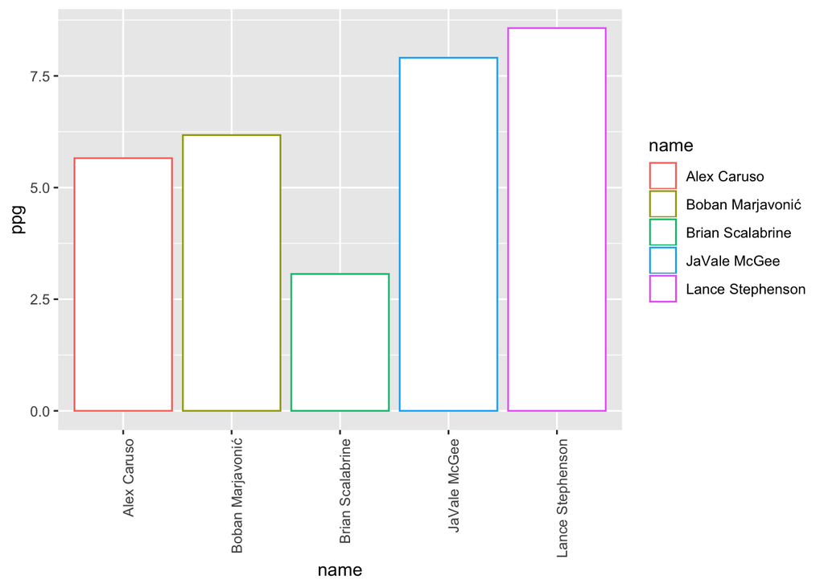

```r
ppg_table <- tibble(name = "Alex Caruso", ppg = ac_career[1,"PTS"]/ac_career[1,"G"])
ppg_table <- ppg_table %>% add_row(name = "Boban Marjavonić", ppg = bm_career[1,"PTS"]/bm_career[1,"G"])
ppg_table <- ppg_table %>% add_row(name = "JaVale McGee", ppg = jm_career[1,"PTS"]/jm_career[1,"G"])
ppg_table <- ppg_table %>% add_row(name = "Brian Scalabrine", ppg = bs_career[1,"PTS"]/bs_career[1,"G"])
ppg_table <- ppg_table %>% add_row(name = "Lance Stephenson", ppg = ls_career[1,"PTS"]/ls_career[1,"G"])
ggplot(ppg_table, aes(x=name,y = ppg, color = name)) + theme(axis.text.x = element_text(angle = 90, hjust = 1)) + geom_bar(stat = "identity", fill = "white")
```

As clearly shown by the graph, Lance is the top scorer with 8.57 ppg, followed by JaVale (7.91), Boban (6.17), Alex (5.66), and Brian (3.07) (in that order). I will assign points to the player to use later as a way to find out who is the best (top: 4 points, second: 3 points, third: 2 points, fourth: 1 point, and last: 0 points). Example of this scoring:

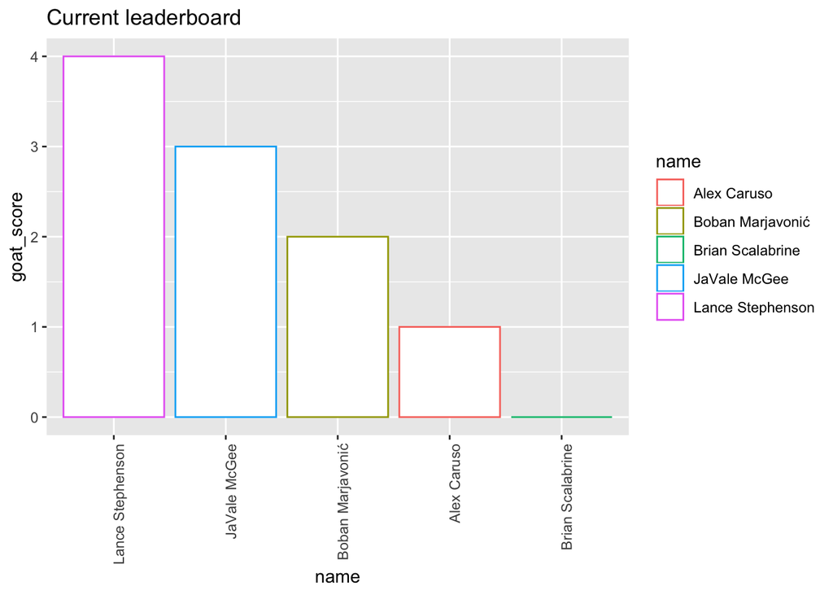

```r
ggplot(goat, aes(x= reorder(name, -goat_score),y = goat_score, color = name)) + xlab("name") + labs(title = "Current leaderboard") + theme(axis.text.x = element_text(angle = 90, hjust = 1)) + geom_bar(stat = "identity", fill = "white")
```

#### b. Rebound per Game

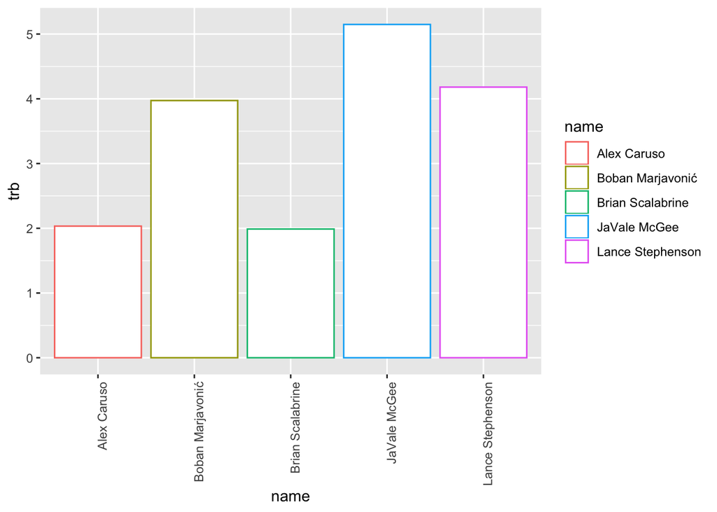

```r
trb_table <- tibble(name = "Alex Caruso", trb = ac_career[1,"TRB"]/ac_career[1,"G"])
trb_table <- trb_table %>% add_row(name = "Boban Marjavonić", trb = bm_career[1,"TRB"]/bm_career[1,"G"])
trb_table <- trb_table %>% add_row(name = "JaVale McGee", trb = jm_career[1,"TRB"]/jm_career[1,"G"])
trb_table <- trb_table %>% add_row(name = "Brian Scalabrine", trb = bs_career[1,"TRB"]/bs_career[1,"G"])
trb_table <- trb_table %>% add_row(name = "Lance Stephenson", trb = ls_career[1,"TRB"]/ls_career[1,"G"])
ggplot(trb_table, aes(x=name,y = trb, color = name)) + theme(axis.text.x = element_text(angle = 90, hjust = 1)) + geom_bar(stat = "identity", fill = "white")
```

Based on the graph, JaVale is the top rebounder over his career (5.15 rpg), followed by Lance (4.18), Boban (3.97), Alex (2.03), and Brian (1.99). I will assign points to the player to use later as a way to find out who is the best (top: 4 points, second: 3 points, third: 2 points, fourth: 1 point, and last: 0 points).

#### c. Assists per Game

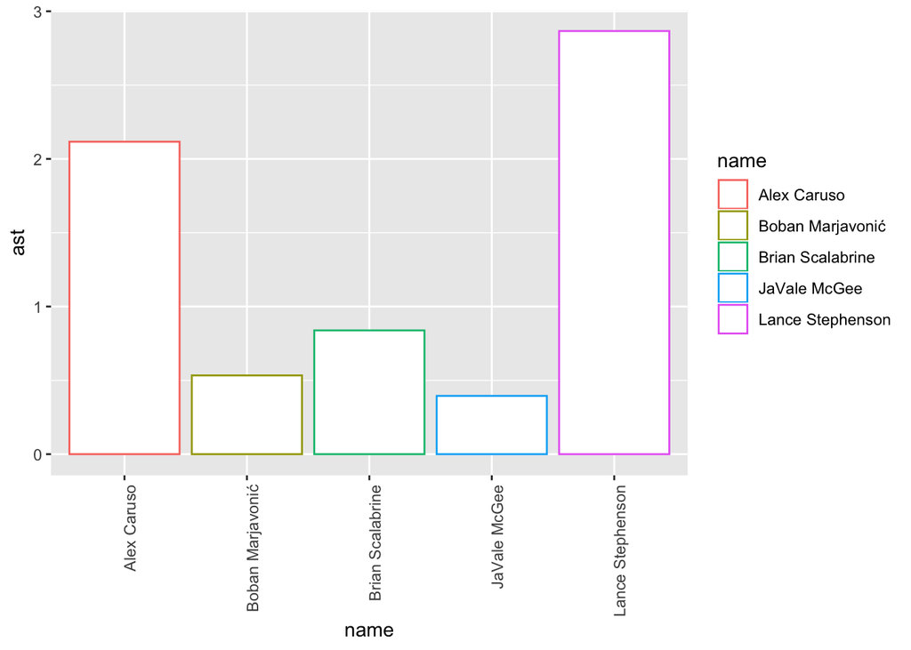

```r
ast_table <- tibble(name = "Alex Caruso", ast = ac_career[1,"AST"]/ac_career[1,"G"])
ast_table <- ast_table %>% add_row(name = "Boban Marjavonić", ast = bm_career[1,"AST"]/bm_career[1,"G"])
ast_table <- ast_table %>% add_row(name = "JaVale McGee", ast = jm_career[1,"AST"]/jm_career[1,"G"])
ast_table <- ast_table %>% add_row(name = "Brian Scalabrine", ast = bs_career[1,"AST"]/bs_career[1,"G"])
ast_table <- ast_table %>% add_row(name = "Lance Stephenson", ast = ls_career[1,"AST"]/ls_career[1,"G"])
ggplot(ast_table, aes(x=name,y = ast, color = name)) + theme(axis.text.x = element_text(angle = 90, hjust = 1)) + geom_bar(stat = "identity", fill = "white")
```

Based on the graph, Lance has the highest assists per game over his career (2.87 apg), followed by Alex (2.12), Brian (0.84), Boban (0.53), and JaVale (0.39). I will assign points to the player to use later as a way to find out who is the best (top: 4 points, second: 3 points, third: 2 points, fourth: 1 point, and last: 0 points).

#### d. Steals per Game

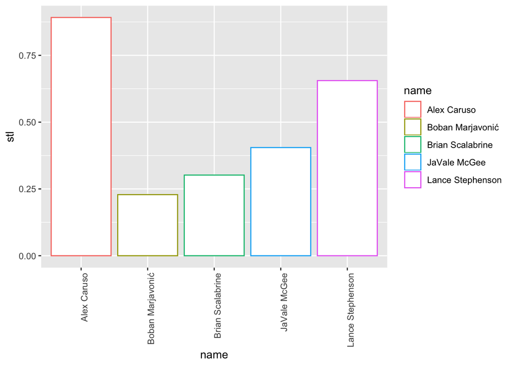

```r
stl_table <- tibble(name = "Alex Caruso", stl = ac_career[1,"STL"]/ac_career[1,"G"])
stl_table <- stl_table %>% add_row(name = "Boban Marjavonić", stl = bm_career[1,"STL"]/bm_career[1,"G"])
stl_table <- stl_table %>% add_row(name = "JaVale McGee", stl = jm_career[1,"STL"]/jm_career[1,"G"])
stl_table <- stl_table %>% add_row(name = "Brian Scalabrine", stl = bs_career[1,"STL"]/bs_career[1,"G"])
stl_table <- stl_table %>% add_row(name = "Lance Stephenson", stl = ls_career[1,"STL"]/ls_career[1,"G"])
ggplot(stl_table, aes(x=name,y = stl, color = name)) + theme(axis.text.x = element_text(angle = 90, hjust = 1)) + geom_bar(stat = "identity", fill = "white")
```

Based on the graph, Alex has the highest steals per game over his career (0.89 spg), followed by Lance (0.65), JaVale (0.4), Brian (0.3), and Boban (0.23). I will assign points to the player to use later as a way to find out who is the best (top: 4 points, second: 3 points, third: 2 points, fourth: 1 point, and last: 0 points).

#### e. Blocks per Game

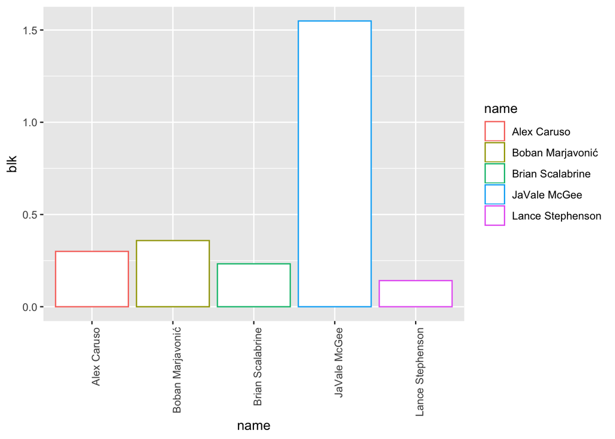

```r
blk_table <- tibble(name = "Alex Caruso", blk = ac_career[1,"BLK"]/ac_career[1,"G"])
blk_table <- blk_table %>% add_row(name = "Boban Marjavonić", blk = bm_career[1,"BLK"]/bm_career[1,"G"])
blk_table <- blk_table %>% add_row(name = "JaVale McGee", blk = jm_career[1,"BLK"]/jm_career[1,"G"])
blk_table <- blk_table %>% add_row(name = "Brian Scalabrine", blk = bs_career[1,"BLK"]/bs_career[1,"G"])
blk_table <- blk_table %>% add_row(name = "Lance Stephenson", blk = ls_career[1,"BLK"]/ls_career[1,"G"])
ggplot(blk_table, aes(x=name,y = blk, color = name)) + theme(axis.text.x = element_text(angle = 90, hjust = 1)) + geom_bar(stat = "identity", fill = "white")
```

Based on the graph, JaVale has the highest blocks per game over his career (1.54 bpg), followed by Boban (0.36), Alex (0.3), Brian (0.23), and Lance (0.14). I will assign points to the player to use later as a way to find out who is the best (top: 4 points, second: 3 points, third: 2 points, fourth: 1 point, and last: 0 points).

#### f. Turnovers per Game

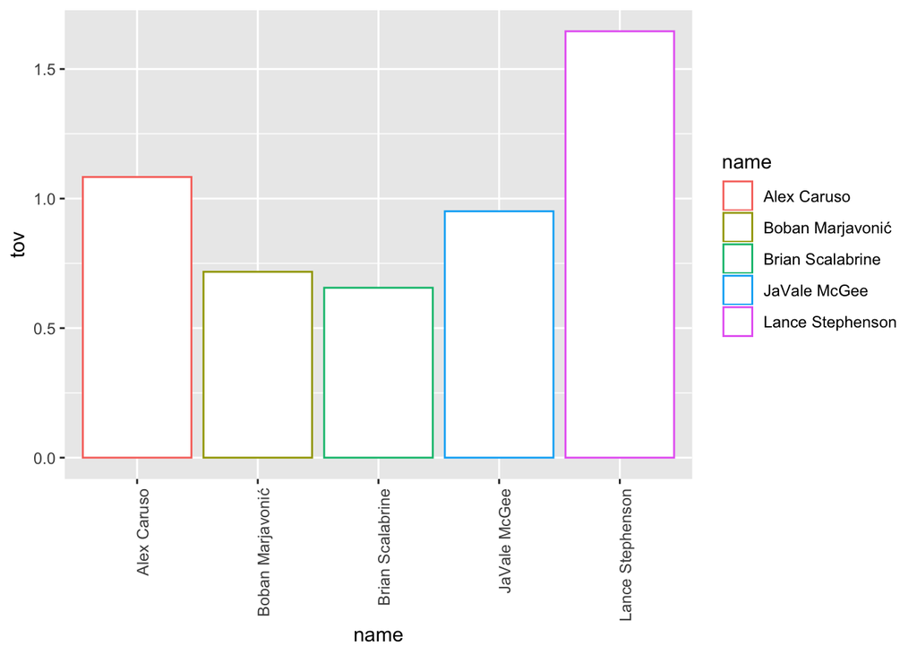

```r
tov_table <- tibble(name = "Alex Caruso", tov = ac_career[1,"TOV"]/ac_career[1,"G"])
tov_table <- tov_table %>% add_row(name = "Boban Marjavonić", tov = bm_career[1,"TOV"]/bm_career[1,"G"])
tov_table <- tov_table %>% add_row(name = "JaVale McGee", tov = jm_career[1,"TOV"]/jm_career[1,"G"])
tov_table <- tov_table %>% add_row(name = "Brian Scalabrine", tov = bs_career[1,"TOV"]/bs_career[1,"G"])
tov_table <- tov_table %>% add_row(name = "Lance Stephenson", tov = ls_career[1,"TOV"]/ls_career[1,"G"])
ggplot(tov_table, aes(x=name,y = tov, color = name)) + theme(axis.text.x = element_text(angle = 90, hjust = 1)) + geom_bar(stat = "identity", fill = "white")
```

For the next two categories, the lower average is better so based on the graph, Brian has the lowest turnovers per game over his career (0.66 tpg), followed by Boban (0.72), JaVale (0.95), Alex (1.08), and Lance (1.65). I will assign points to the player to use later as a way to find out who is the best (top: 4 points, second: 3 points, third: 2 points, fourth: 1 point, and last: 0 points).

#### g. Personal Fouls per Game

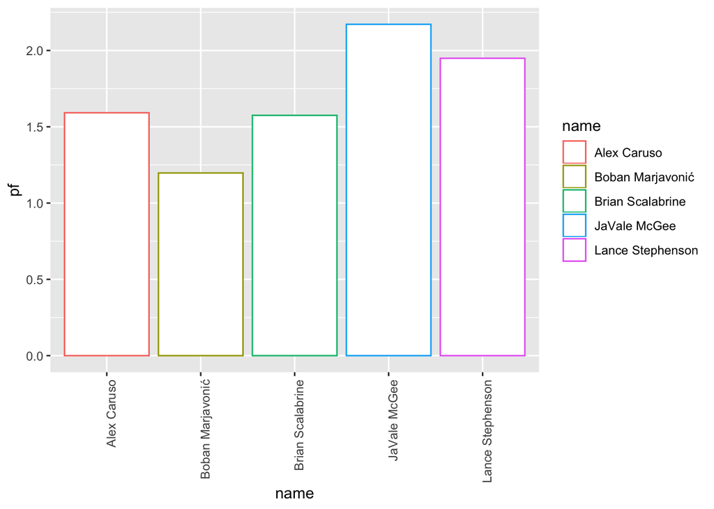

```r
pf_table <- tibble(name = "Alex Caruso", pf = ac_career[1,"PF"]/ac_career[1,"G"])
pf_table <- pf_table %>% add_row(name = "Boban Marjavonić", pf = bm_career[1,"PF"]/bm_career[1,"G"])
pf_table <- pf_table %>% add_row(name = "JaVale McGee", pf = jm_career[1,"PF"]/jm_career[1,"G"])
pf_table <- pf_table %>% add_row(name = "Brian Scalabrine", pf = bs_career[1,"PF"]/bs_career[1,"G"])
pf_table <- pf_table %>% add_row(name = "Lance Stephenson", pf = ls_career[1,"PF"]/ls_career[1,"G"])
ggplot(pf_table, aes(x=name,y = pf, color = name)) + theme(axis.text.x = element_text(angle = 90, hjust = 1)) + geom_bar(stat = "identity", fill = "white")
```

Based on the graph, Boban has the lowest personal fouls per game over his career (1.2 fpg), followed by Brian (1.58), Alex (1.59), Lance (1.95), and JaVale (2.17). I will assign points to the player to use later as a way to find out who is the best (top: 4 points, second: 3 points, third: 2 points, fourth: 1 point, and last: 0 points). After the all of the statistical categories, the table is as follows

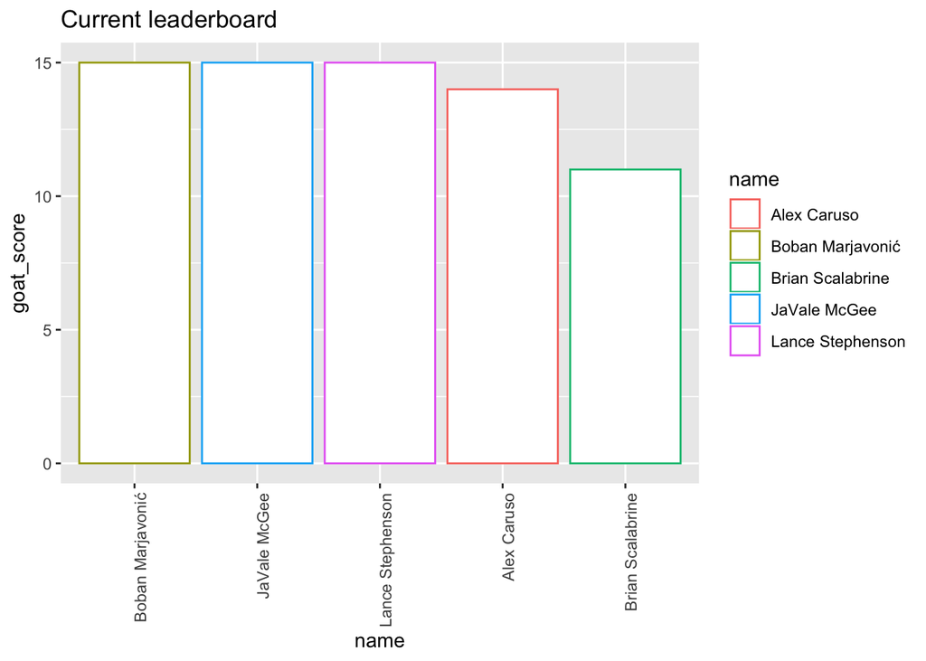

```r
ggplot(goat, aes(x= reorder(name, -goat_score),y = goat_score, color = name)) + xlab("name") + labs(title = "Current leaderboard") + theme(axis.text.x = element_text(angle = 90, hjust = 1)) + geom_bar(stat = "identity", fill = "white")
```

As the table stands after the statistical per game stats, Boban, JaVale and Lance are tied (15 points) for the top spot. Followed by Alex Caruso at 14 points and Brian Scalabrine at 11 points.

## 3. Statistical Comparison per 36 minutes

#### a. Points per 36 minutes

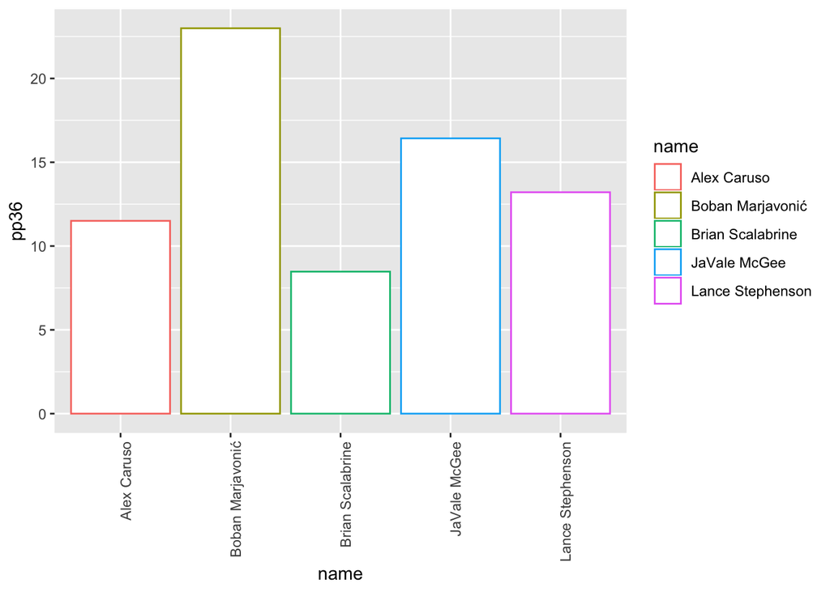

```r
pp36_table <- tibble(name = "Alex Caruso", pp36 = (ac_career[1,"PTS"]/ac_career[1,"G"])*(36/(ac_career[1,"MP"]/ac_career[1,"G"])))
pp36_table <- pp36_table %>% add_row(name = "Boban Marjavonić", pp36 = (bm_career[1,"PTS"]/bm_career[1,"G"])*(36/(bm_career[1,"MP"]/bm_career[1,"G"])))
pp36_table <- pp36_table %>% add_row(name = "JaVale McGee", pp36 = (jm_career[1,"PTS"]/jm_career[1,"G"])*(36/(jm_career[1,"MP"]/jm_career[1,"G"])))
pp36_table <- pp36_table %>% add_row(name = "Brian Scalabrine", pp36 = (bs_career[1,"PTS"]/bs_career[1,"G"])*(36/(bs_career[1,"MP"]/bs_career[1,"G"])))
pp36_table <- pp36_table %>% add_row(name = "Lance Stephenson", pp36 = (ls_career[1,"PTS"]/ls_career[1,"G"])*(36/(ls_career[1,"MP"]/ls_career[1,"G"])))
ggplot(pp36_table, aes(x=name,y = pp36, color = name)) + theme(axis.text.x = element_text(angle = 90, hjust = 1)) + geom_bar(stat = "identity", fill = "white")
```

As clearly shown by the graph, Boban is the top scorer with 22.99 pp36, followed by JaVale (16.43), Lance (13.21), Alex (11.5), and Brian (8.47) (in that order). I will assign points to the player to use later as a way to find out who is the best (top: 8 points, second: 6 points, third: 4 points, fourth: 2 point, and last: 0 points). Example of this scoring:

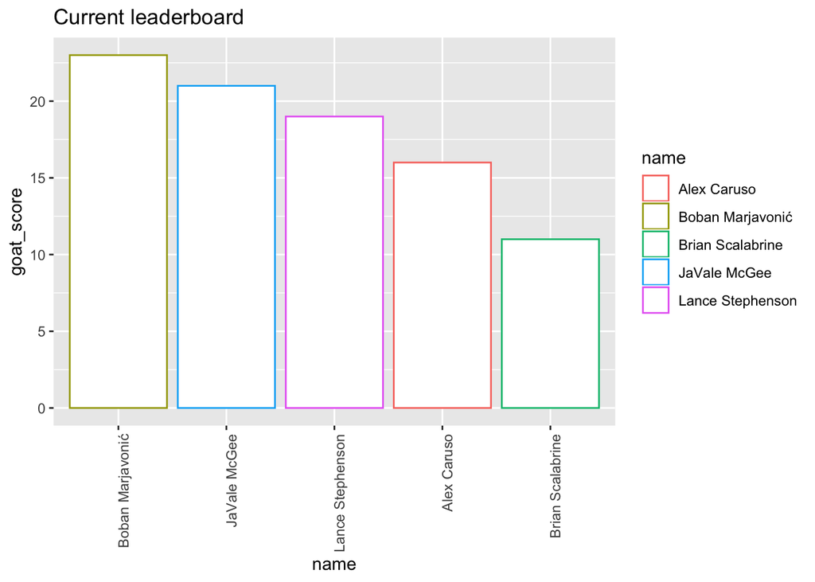

```r
ggplot(goat, aes(x= reorder(name, -goat_score),y = goat_score, color = name)) + xlab("name") + labs(title = "Current leaderboard") + theme(axis.text.x = element_text(angle = 90, hjust = 1)) + geom_bar(stat = "identity", fill = "white")
```

#### b. Rebound per 36 minutes

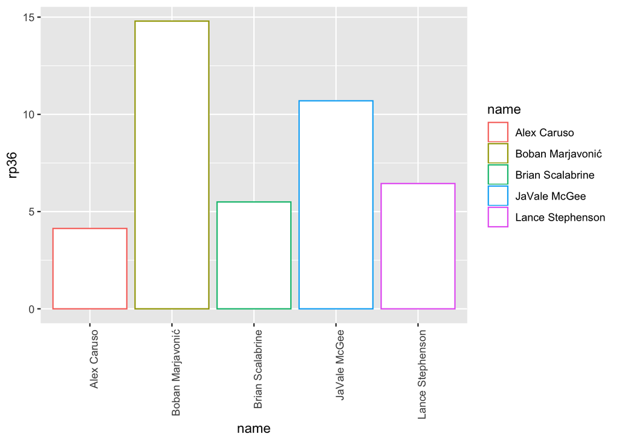

```r
rp36_table <- tibble(name = "Alex Caruso", rp36 = (ac_career[1,"TRB"]/ac_career[1,"G"])*(36/(ac_career[1,"MP"]/ac_career[1,"G"])))
rp36_table <- rp36_table %>% add_row(name = "Boban Marjavonić", rp36 = (bm_career[1,"TRB"]/bm_career[1,"G"])*(36/(bm_career[1,"MP"]/bm_career[1,"G"])))
rp36_table <- rp36_table %>% add_row(name = "JaVale McGee", rp36 = (jm_career[1,"TRB"]/jm_career[1,"G"])*(36/(jm_career[1,"MP"]/jm_career[1,"G"])))
rp36_table <- rp36_table %>% add_row(name = "Brian Scalabrine", rp36 = (bs_career[1,"TRB"]/bs_career[1,"G"])*(36/(bs_career[1,"MP"]/bs_career[1,"G"])))
rp36_table <- rp36_table %>% add_row(name = "Lance Stephenson", rp36 = (ls_career[1,"TRB"]/ls_career[1,"G"])*(36/(ls_career[1,"MP"]/ls_career[1,"G"])))
ggplot(rp36_table, aes(x=name,y = rp36, color = name)) + theme(axis.text.x = element_text(angle = 90, hjust = 1)) + geom_bar(stat = "identity", fill = "white")
```

Based on the graph, Boban is the top rebounder (14.79 rp36), followed by JaVale (10.7), Lance (6.44), Brian (5.5), and Alex (4.13). I will assign points to the player to use later as a way to find out who is the best (top: 8 points, second: 6 points, third: 4 points, fourth: 2 point, and last: 0 points).

#### c. Assists per 36 minutes

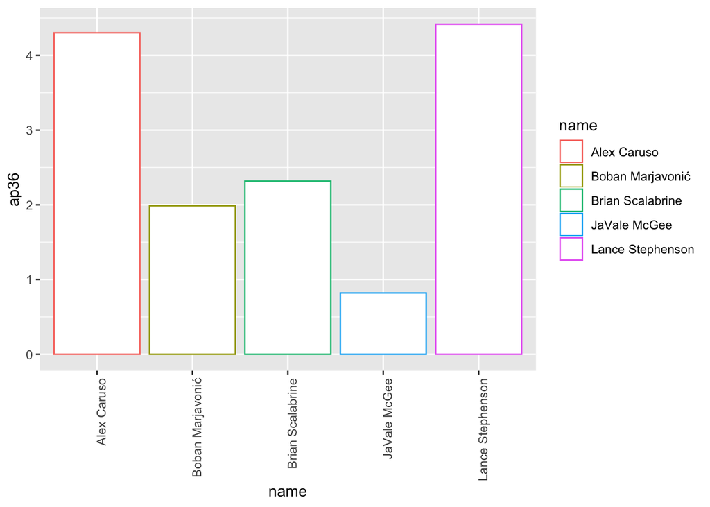

```r
ap36_table <- tibble(name = "Alex Caruso", ap36 = (ac_career[1,"AST"]/ac_career[1,"G"])*(36/(ac_career[1,"MP"]/ac_career[1,"G"])))
ap36_table <- ap36_table %>% add_row(name = "Boban Marjavonić", ap36 = (bm_career[1,"AST"]/bm_career[1,"G"])*(36/(bm_career[1,"MP"]/bm_career[1,"G"])))
ap36_table <- ap36_table %>% add_row(name = "JaVale McGee", ap36 = (jm_career[1,"AST"]/jm_career[1,"G"])*(36/(jm_career[1,"MP"]/jm_career[1,"G"])))
ap36_table <- ap36_table %>% add_row(name = "Brian Scalabrine", ap36 = (bs_career[1,"AST"]/bs_career[1,"G"])*(36/(bs_career[1,"MP"]/bs_career[1,"G"])))
ap36_table <- ap36_table %>% add_row(name = "Lance Stephenson", ap36 = (ls_career[1,"AST"]/ls_career[1,"G"])*(36/(ls_career[1,"MP"]/ls_career[1,"G"])))
ggplot(ap36_table, aes(x=name,y = ap36, color = name)) + theme(axis.text.x = element_text(angle = 90, hjust = 1)) + geom_bar(stat = "identity", fill = "white")
```

Based on the graph, Lance has the highest assists per 36 minuets (4.42 ap36), followed by Alex (4.3), Brian (2.32), Boban (1.99), and JaVale (0.82). I will assign points to the player to use later as a way to find out who is the best (top: 8 points, second: 6 points, third: 4 points, fourth: 2 point, and last: 0 points).

#### d. Steals per 36 minutes

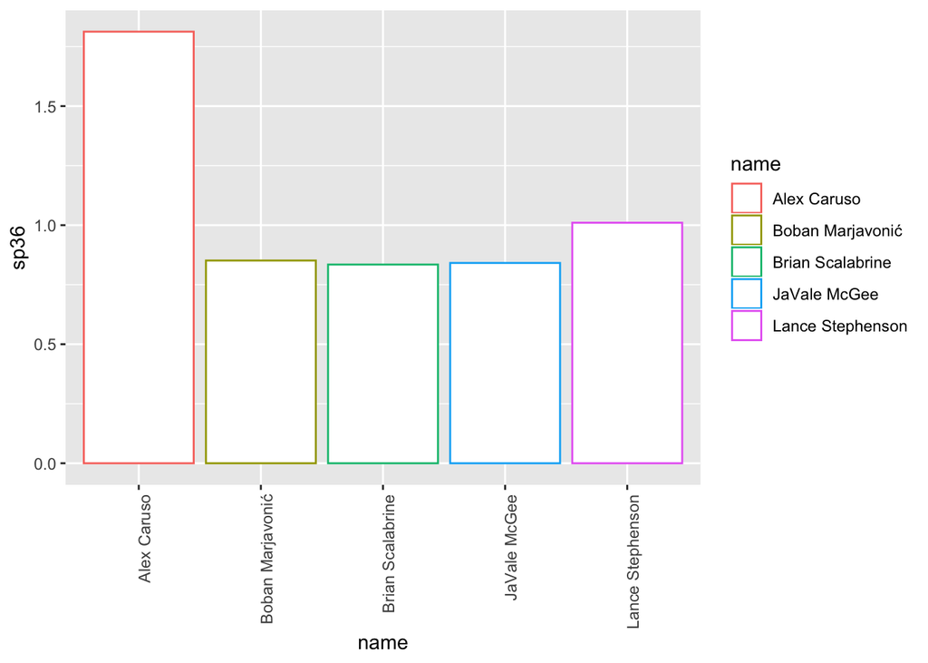

```r
sp36_table <- tibble(name = "Alex Caruso", sp36 = (ac_career[1,"STL"]/ac_career[1,"G"])*(36/(ac_career[1,"MP"]/ac_career[1,"G"])))
sp36_table <- sp36_table %>% add_row(name = "Boban Marjavonić", sp36 = (bm_career[1,"STL"]/bm_career[1,"G"])*(36/(bm_career[1,"MP"]/bm_career[1,"G"])))
sp36_table <- sp36_table %>% add_row(name = "JaVale McGee", sp36 = (jm_career[1,"STL"]/jm_career[1,"G"])*(36/(jm_career[1,"MP"]/jm_career[1,"G"])))
sp36_table <- sp36_table %>% add_row(name = "Brian Scalabrine", sp36 = (bs_career[1,"STL"]/bs_career[1,"G"])*(36/(bs_career[1,"MP"]/bs_career[1,"G"])))
sp36_table <- sp36_table %>% add_row(name = "Lance Stephenson", sp36 = (ls_career[1,"STL"]/ls_career[1,"G"])*(36/(ls_career[1,"MP"]/ls_career[1,"G"])))
ggplot(sp36_table, aes(x=name,y = sp36, color = name)) + theme(axis.text.x = element_text(angle = 90, hjust = 1)) + geom_bar(stat = "identity", fill = "white")
```

Based on the graph, Alex has the highest steals per 36 minutes (1.81 sp36), followed by Lance (1.01), Boban (0.85), JaVale (0.84), and Brian (0.83). I will assign points to the player to use later as a way to find out who is the best (top: 8 points, second: 6 points, third: 4 points, fourth: 2 point, and last: 0 points).

#### e. Blocks per 36 minutes

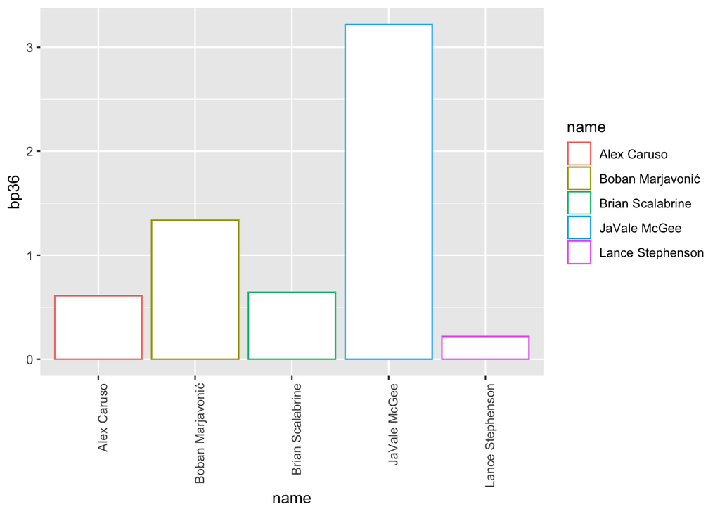

```r
bp36_table <- tibble(name = "Alex Caruso", bp36 = (ac_career[1,"BLK"]/ac_career[1,"G"])*(36/(ac_career[1,"MP"]/ac_career[1,"G"])))
bp36_table <- bp36_table %>% add_row(name = "Boban Marjavonić", bp36 = (bm_career[1,"BLK"]/bm_career[1,"G"])*(36/(bm_career[1,"MP"]/bm_career[1,"G"])))
bp36_table <- bp36_table %>% add_row(name = "JaVale McGee", bp36 = (jm_career[1,"BLK"]/jm_career[1,"G"])*(36/(jm_career[1,"MP"]/jm_career[1,"G"])))
bp36_table <- bp36_table %>% add_row(name = "Brian Scalabrine", bp36 = (bs_career[1,"BLK"]/bs_career[1,"G"])*(36/(bs_career[1,"MP"]/bs_career[1,"G"])))
bp36_table <- bp36_table %>% add_row(name = "Lance Stephenson", bp36 = (ls_career[1,"BLK"]/ls_career[1,"G"])*(36/(ls_career[1,"MP"]/ls_career[1,"G"])))
ggplot(bp36_table, aes(x=name,y = bp36, color = name)) + theme(axis.text.x = element_text(angle = 90, hjust = 1)) + geom_bar(stat = "identity", fill = "white")
```

Based on the graph, JaVale has the highest blocks per 36 minutes (3.22 bpg), followed by Boban (1.34), Brian (0.64), Alex (0.61), and Lance (0.22). I will assign points to the player to use later as a way to find out who is the best (top: 8 points, second: 6 points, third: 4 points, fourth: 2 point, and last: 0 points).

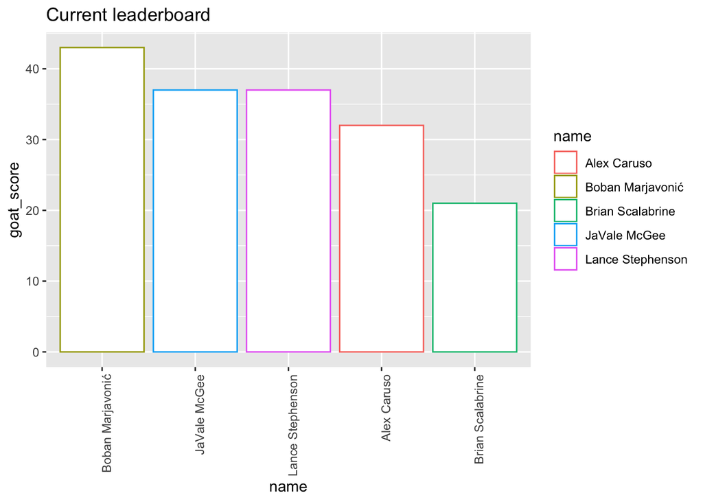

```r
ggplot(goat, aes(x= reorder(name, -goat_score),y = goat_score, color = name)) + xlab("name") + labs(title = "Current leaderboard") + theme(axis.text.x = element_text(angle = 90, hjust = 1)) + geom_bar(stat = "identity", fill = "white")
```

As the table stands after the statistical comparison of per 36 minutes stats, Boban takes first (43 points) followed by JaVale and Lance at 37 points, then Alex Caruso at 32 points and Brian Scalabrine at 21 points.

## 3. Player Efficiency

Player efficiency will be broken down into six different sections: 2-point field goal percentage, 3-point field goal percentage, free throw percentage, overall field goal percentage, effective field goal percentage (which takes in account that a three point is worth more than a two pointer), and a player efficiency rating (explained later).

#### a. 2-Point field goal percentage

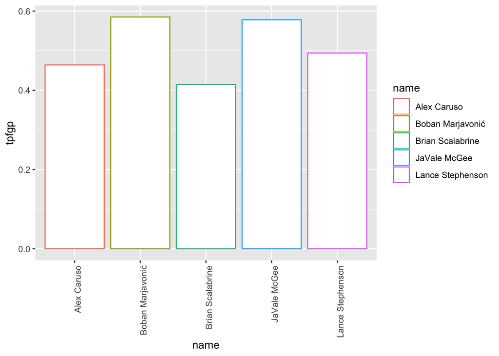

```r
tpfgp_table <- tibble(name = "Alex Caruso", tpfgp = ac_eff[1,"2P%"])
tpfgp_table <- tpfgp_table %>% add_row(name = "Boban Marjavonić", tpfgp = bm_eff[1,"2P%"])
tpfgp_table <- tpfgp_table %>% add_row(name = "JaVale McGee", tpfgp = jm_eff[1,"2P%"])
tpfgp_table <- tpfgp_table %>% add_row(name = "Brian Scalabrine", tpfgp = bs_eff[1,"2P%"])
tpfgp_table <- tpfgp_table %>% add_row(name = "Lance Stephenson", tpfgp = ls_eff[1,"2P%"])
ggplot(tpfgp_table, aes(x=name,y = tpfgp, color = name)) + theme(axis.text.x = element_text(angle = 90, hjust = 1)) + geom_bar(stat = "identity", fill = "white")
```

Based on the graph, Boban has the highest 2-point field goal percentage over his career (58.5%), followed by JaVale (57.8%), Lance (49.4%), Alex (46.4%), and Brian (41.5%). I will assign points to the player to use later as a way to find out who is the best (top: 4 points, second: 3 points, third: 2 points, fourth: 1 point, and last: 0 points), since the players play different positions and are most likely to take certain shot types over other types.

#### b. 3-Point field goal percentage

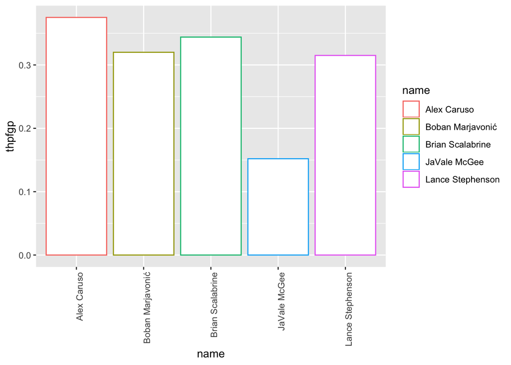

```r
thpfgp_table <- tibble(name = "Alex Caruso", thpfgp = ac_eff[1,"3P%"])
thpfgp_table <- thpfgp_table %>% add_row(name = "Boban Marjavonić", thpfgp = bm_eff[1,"3P%"])
thpfgp_table <- thpfgp_table %>% add_row(name = "JaVale McGee", thpfgp = jm_eff[1,"3P%"])
thpfgp_table <- thpfgp_table %>% add_row(name = "Brian Scalabrine", thpfgp = bs_eff[1,"3P%"])
thpfgp_table <- thpfgp_table %>% add_row(name = "Lance Stephenson", thpfgp = ls_eff[1,"3P%"])
ggplot(thpfgp_table, aes(x=name,y = thpfgp, color = name)) + theme(axis.text.x = element_text(angle = 90, hjust = 1)) + geom_bar(stat = "identity", fill = "white")
```

Based on the graph, Alex has the highest 3-point field goal percentage over his career (37.5%), followed by Brian (34.4%), Boban (32%), Lance (31.5%), and JaVale (15.2%). I will assign points to the player to use later as a way to find out who is the best (top: 4 points, second: 3 points, third: 2 points, fourth: 1 point, and last: 0 points), since the players play different positions.

#### c. Free Throw Percentage

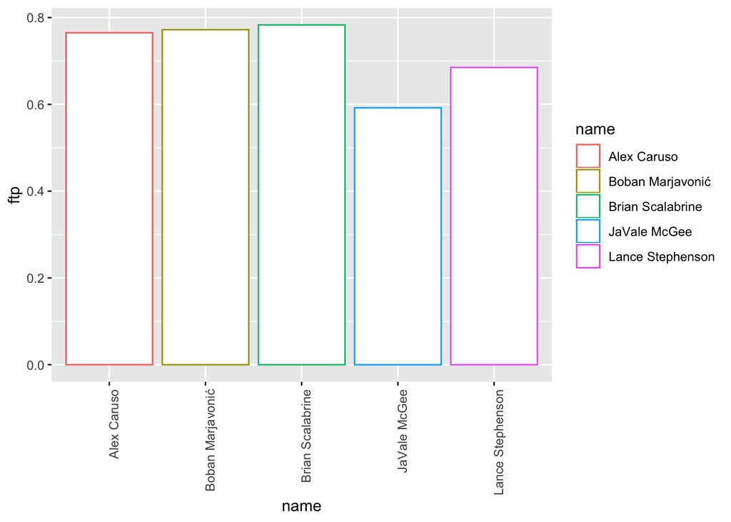

```r
ftp_table <- tibble(name = "Alex Caruso", ftp = ac_eff[1,"FT%"])
ftp_table <- ftp_table %>% add_row(name = "Boban Marjavonić", ftp = bm_eff[1,"FT%"])
ftp_table <- ftp_table %>% add_row(name = "JaVale McGee", ftp = jm_eff[1,"FT%"])
ftp_table <- ftp_table %>% add_row(name = "Brian Scalabrine", ftp = bs_eff[1,"FT%"])
ftp_table <- ftp_table %>% add_row(name = "Lance Stephenson", ftp = ls_eff[1,"FT%"])
ggplot(ftp_table, aes(x=name,y = ftp, color = name)) + theme(axis.text.x = element_text(angle = 90, hjust = 1)) + geom_bar(stat = "identity", fill = "white")
```

Based on the graph, Brian has the highest free throw percentage over his career (78.3%), followed by Boban (77.2%), Alex (76.5%), Lance (68.5%), and JaVale (59.2%). I will assign points to the player to use later as a way to find out who is the best (top: 4 points, second: 3 points, third: 2 points, fourth: 1 point, and last: 0 points), since the players play different positions.

#### d. Overall Field Goal Percentage

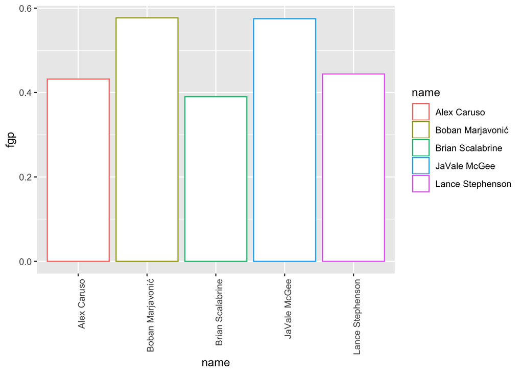

```r
fgp_table <- tibble(name = "Alex Caruso", fgp = ac_eff[1,"FG%"])
fgp_table <- fgp_table %>% add_row(name = "Boban Marjavonić", fgp = bm_eff[1,"FG%"])
fgp_table <- fgp_table %>% add_row(name = "JaVale McGee", fgp = jm_eff[1,"FG%"])
fgp_table <- fgp_table %>% add_row(name = "Brian Scalabrine", fgp = bs_eff[1,"FG%"])
fgp_table <- fgp_table %>% add_row(name = "Lance Stephenson", fgp = ls_eff[1,"FG%"])
ggplot(fgp_table, aes(x=name,y = fgp, color = name)) + theme(axis.text.x = element_text(angle = 90, hjust = 1)) + geom_bar(stat = "identity", fill = "white")
```

Based on the graph, Boban has the highest overall field goal percentage over his career (57.7%), followed by Javale (57.5%), Lance (44.4%), Alex (43.2%), and Brian (39%). I will assign points to the player to use later as a way to find out who is the best (top: 4 points, second: 3 points, third: 2 points, fourth: 1 point, and last: 0 points), since the players play different positions.

#### e. Effective Field Goal Percentage

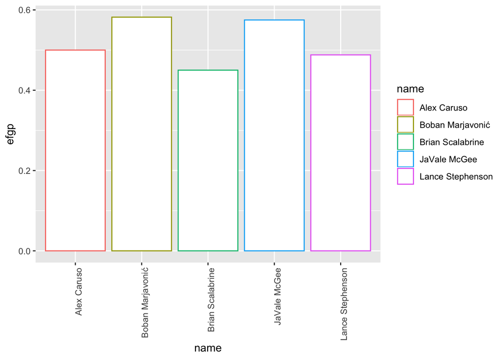

```r
efgp_table <- tibble(name = "Alex Caruso", efgp = ac_eff[1,"eFG%"])
efgp_table <- efgp_table %>% add_row(name = "Boban Marjavonić", efgp = bm_eff[1,"eFG%"])
efgp_table <- efgp_table %>% add_row(name = "JaVale McGee", efgp = jm_eff[1,"eFG%"])
efgp_table <- efgp_table %>% add_row(name = "Brian Scalabrine", efgp = bs_eff[1,"eFG%"])
efgp_table <- efgp_table %>% add_row(name = "Lance Stephenson", efgp = ls_eff[1,"eFG%"])
ggplot(efgp_table, aes(x=name,y = efgp, color = name)) + theme(axis.text.x = element_text(angle = 90, hjust = 1)) + geom_bar(stat = "identity", fill = "white")
```

Based on the graph, Boban has the highest effective field goal percentage over his career (58.2%), followed by Javale (57.5%), Alex (50%), Lance (48.8%), and Brian (45%). I will assign points to the player to use later as a way to find out who is the best (top: 8 points, second: 6 points, third: 4 points, fourth: 2 point, and last: 0 points)

#### f. Custom Player Efficiency Rating

The way I constructed my PER was by taking the effective field goal percentage * points per minutes played + rebounds per minutes played + assists per minutes played.

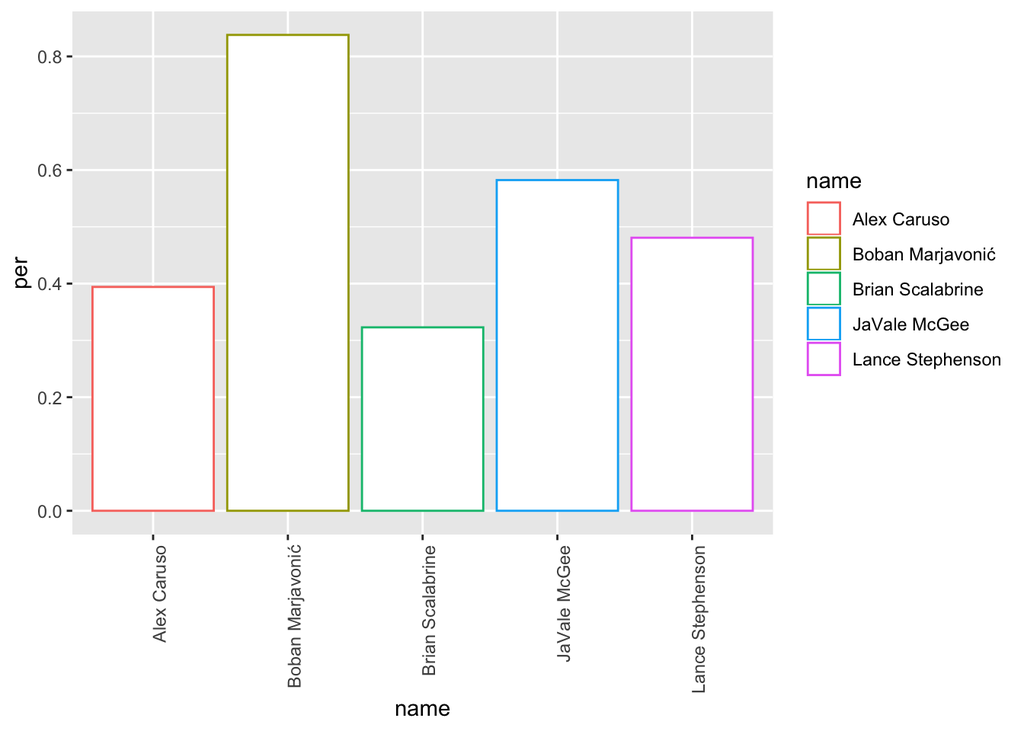

```r
per_table <- tibble(name = "Alex Caruso", per = (ac_eff[1,"eFG%"]*(ac_career[1,"PTS"]/ac_career[1,"MP"]))+(ac_career[1,"TRB"]/ac_career[1,"MP"])+(ac_career[1,"AST"]/ac_career[1,"MP"]))
per_table <- per_table %>% add_row(name = "Boban Marjavonić", per = (bm_eff[1,"eFG%"]*(bm_career[1,"PTS"]/bm_career[1,"MP"]))+(bm_career[1,"TRB"]/bm_career[1,"MP"])+(bm_career[1,"AST"]/bm_career[1,"MP"]))
per_table <- per_table %>% add_row(name = "JaVale McGee", per = (jm_eff[1,"eFG%"]*(jm_career[1,"PTS"]/jm_career[1,"MP"]))+(jm_career[1,"TRB"]/jm_career[1,"MP"])+(jm_career[1,"AST"]/jm_career[1,"MP"]))
per_table <- per_table %>% add_row(name = "Brian Scalabrine", per = (bs_eff[1,"eFG%"]*(bs_career[1,"PTS"]/bs_career[1,"MP"]))+(bs_career[1,"TRB"]/bs_career[1,"MP"])+(bs_career[1,"AST"]/bs_career[1,"MP"]))
per_table <- per_table %>% add_row(name = "Lance Stephenson", per = (ls_eff[1,"eFG%"]*(ls_career[1,"PTS"]/ls_career[1,"MP"]))+(ls_career[1,"TRB"]/ls_career[1,"MP"])+(ls_career[1,"AST"]/ls_career[1,"MP"]))
ggplot(per_table, aes(x=name, y = per, color = name)) + theme(axis.text.x = element_text(angle = 90, hjust = 1)) + geom_bar(stat = "identity", fill = "white")
```

```r
per_table
```

```
## # A tibble: 5 x 2
##   name               per
##   <chr>            <dbl>
## 1 Alex Caruso      0.394
## 2 Boban Marjavonić 0.838
## 3 JaVale McGee     0.582
## 4 Brian Scalabrine 0.323
## 5 Lance Stephenson 0.481
```

Based on the graph, Boban has the highest PER over his career (.83), followed by JaVale (.58), Lance (.48), Alex (.39), and Brian (.32). I will assign points to the player to use later as a way to find out who is the best (top: 12 points, second: 9 points, third: 6 points, fourth: 3 point, and last: 0 points), since the PER should be the most important statistic.

## 4. Conclusion

In conclusion, after all this analysis of the players, Boban Marjavonić (76 points) is by far the GOAT statistically of the group. In second was JaVale McGee (58 points), followed by Lance Stephenson (51 points), Alex Caruso (47 points), and Brian Scalabrine (28 points). Instead of talking MJ and LeBron, we should be talking about Boban and his incredible skills as a efficient role player. Here is a line graph of the leaderboard throughout the project.

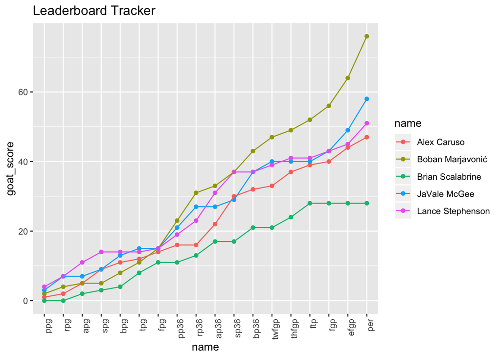

```r
library(tidyr)
line_t <- line_table %>% gather(key = stats, value = goat_score, ppg:per)
line_t$stats <- factor(line_t$stats, levels = (unique(line_t$stats)))
ggplot(line_t, aes(x = stats, y = goat_score, group = name, color = name)) + xlab("name") + labs(title = "Leaderboard Tracker") + theme(axis.text.x = element_text(angle = 90, hjust = 1)) + geom_point() + geom_line()
```